# Air quality Synthetic Control

Auto-converted

2025-12-09

# Background

- **Author**: `<Ju-Chien, Yao>`
- **Created At**: `<2025/11/03>`
- **Research Motivation and Context (why are we interested in the findings?)：** We want to see how the air quality changes in different regions after the implementation of congestion fee.
- **Main Findings and Takeaways：** The regional effect is not apparent. Maybe some control variable should be added.
- **Future Direciton：** Add temperature, precipitation and other climate variables; Apply DID or GSC.

```r
# Load packages here
remove(list = ls())
library(sf)
library(tmap)
library(dplyr)
library(tidyr)
library(arrow)
library(ggplot2)
library(lubridate)
library(tidysynth)
library(stringr)
library(fixest)
```

### 讀資料

```r
# Load input data here and please finish all the data manipulation here.
# Assuming your dataframe is named 'control'

## Reading Data
climate = read.csv("C:/114-1_Autumn/Data_science_and_social_inquiry/data/air_quality/processed_pm2.5_AQI.csv") %>%
  dplyr::select(c(-X)) %>%
  mutate(Date = as.Date(Date, format = "%m/%d/%Y"))

## Produce weekly data
climate_weekly <- climate %>%
  # Create a "week" variable from the datetime column
  mutate(week = floor_date(Date, "week")) %>%
  # Group by week and region (if multiple locations)
  group_by(region, week) %>%
  # Compute weekly means
  summarise(
    PM2.5_avg = mean(`PM2.5`, na.rm = TRUE),
    AQI_avg  = mean(AQI, na.rm = TRUE),
    .groups = "drop"
  )

# Finish this block by printing the first ten observations of the data.

## Take the main data (the read-in-to-use one) as example
head(climate_weekly, 10)
```

```
## # A tibble: 10 × 4
##    region            week       PM2.5_avg AQI_avg
##    <chr>             <date>         <dbl>   <dbl>
##  1 East Harlem North 2023-12-31      8.53    47
##  2 East Harlem North 2024-01-07      3.04    16.8
##  3 East Harlem North 2024-01-14     11.1     54.7
##  4 East Harlem North 2024-01-21     11.7     55
##  5 East Harlem North 2024-01-28      3.92    21.8
##  6 East Harlem North 2024-02-04      6.03    33.7
##  7 East Harlem North 2024-02-11      6.1     34
##  8 East Harlem North 2024-02-18      5.98    33
##  9 East Harlem North 2024-02-25      8.67    41.7
## 10 East Harlem North 2024-03-03      3.33    18.7
```

```r
# Note:
# - You may only read data from /data/processed.
# - Files in /data/processed should already be cleaned and prepared for analysis.
# - Beyond simple filtering of observations or generating a small number of variables,
#   further data manipulation is not allowed. If more extensive changes are needed,
#   update the source data instead.
```

```r
# Before conducting the analysis, report summary statistics for all variables
# that will be used in this notebook:
#   - For numeric variables: mean, min, 25th percentile, median, 75th percentile,
#     max, standard deviation, and number of observations.

# The number of observations
nrow(climate_weekly)
```

```
## [1] 312
```

```r
# For PM2.5
summary(climate_weekly$PM2.5_avg)
```

```
##    Min. 1st Qu.  Median    Mean 3rd Qu.    Max.
##   2.017   5.312   6.950   7.377   8.989  20.133
```

```r
sd(climate_weekly$PM2.5_avg)
```

```
## [1] 2.850868
```

```r
# For AQI
summary(climate_weekly$AQI_avg)
```

```
##    Min. 1st Qu.  Median    Mean 3rd Qu.    Max.
##   12.00   29.27   37.07   37.42   45.43   70.67
```

```r
sd(climate_weekly$AQI_avg)
```

```
## [1] 11.15042
```

```r
#   - For categorical variables: number of observations and the counts/percentages
#     of the ten most frequent categories.
# Conclude this block with the complete summary statistics.
```

## The actual analysis starts below

### Ensure data availability

```r
# Define your cutoff
cutoff_date <- as.Date("2025-03-23")

# Filter the data
scm_data_filtered <- climate_weekly %>%
  filter(week <= cutoff_date)

# CHECK: Run this line to see if the counts are now identical
table(scm_data_filtered$region)
```

```
##
##        East Harlem North             East Village           Manhattanville
##                       65                       65                       65
## Washington Heights North
##                       65
```

### 讀進氣候控制變數

這裡的氣候控制變數資料來自sensoto網站，是一個感測器的彙整資料庫。`control` 是中央公園的資料，包含降水、氣溫跟風速，在政策範圍外；`treatment` 是則位於紐約越戰紀念碑旁，包含氣溫、風速，在政策範圍內。

```r
control = read.csv("C:/114-1_Autumn/Data_science_and_social_inquiry/data/new-weather-data/measurements.csv") %>%
  rename_with(~ case_when(
    .x == "begin" ~ "start_date",
    .x == "end" ~ "end_date",
    # Use str_extract to grab the core variable name (e.g., LIQUID_PRECIPITATION)
    # Then use str_extract again to grab the value type (e.g., _v, _lo, _hi, _c)
    str_detect(.x, "PRECIPITATION") ~ paste0("precip_", str_extract(.x, "_v|_lo|_hi|_c$") %>% str_remove("_")),
    str_detect(.x, "TEMPERATURE") ~ paste0("temp_", str_extract(.x, "_v|_lo|_hi|_c$") %>% str_remove("_")),
    str_detect(.x, "WIND_SPEED_RATE") ~ paste0("wind_", str_extract(.x, "_v|_lo|_hi|_c$") %>% str_remove("_")),
    TRUE ~ .x # Keep other names if they exist
  ))

control = cbind(control, week = scm_data_filtered$week)

treatment = read.csv("C:/114-1_Autumn/Data_science_and_social_inquiry/data/new-weather-treatment-data/measurements.csv") %>%
  rename_with(~ case_when(
    .x == "begin" ~ "start_date",
    .x == "end" ~ "end_date",
    # Use str_extract to grab the core variable name (e.g., LIQUID_PRECIPITATION)
    # Then use str_extract again to grab the value type (e.g., _v, _lo, _hi, _c)
    str_detect(.x, "PRECIPITATION") ~ paste0("precip_", str_extract(.x, "_v|_lo|_hi|_c$") %>% str_remove("_")),
    str_detect(.x, "TEMPERATURE") ~ paste0("temp_", str_extract(.x, "_v|_lo|_hi|_c$") %>% str_remove("_")),
    str_detect(.x, "WIND_SPEED_RATE") ~ paste0("wind_", str_extract(.x, "_v|_lo|_hi|_c$") %>% str_remove("_")),
    TRUE ~ .x # Keep other names if they exist
  ))
```

### 初始 SCM

```r
# Policy start time
intervention_date <- as.Date("2025-01-05")

# New start date based on filtered data
start_date <- min(scm_data_filtered$week)

pm25_out <- scm_data_filtered %>%

  # Initialize
  synthetic_control(
    outcome = PM2.5_avg,
    unit = region,
    time = week,
    i_unit = "East Village",
    i_time = intervention_date,
    generate_placebos = TRUE
  ) %>%

  # Generate Predictors
  generate_predictor(
    time_window = c(start_date, intervention_date - 7),
    avg_pm25 = mean(PM2.5_avg, na.rm = TRUE)
  ) %>%

  # Generate Weights
  generate_weights(optimization_window = c(start_date, intervention_date - 7)) %>%

  # Generate Control
  generate_control()
```

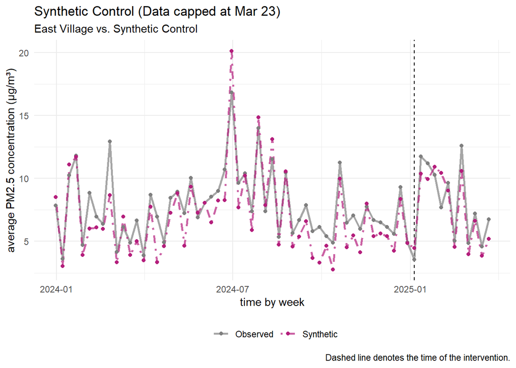

```r
# Plot Trends
pm25_out %>% plot_trends() +
  labs(title = "Synthetic Control (Data capped at Mar 23)",
       subtitle = "East Village vs. Synthetic Control",
       x = "time by week",
       y = "average PM2.5 concentration (μg/m³)")
```

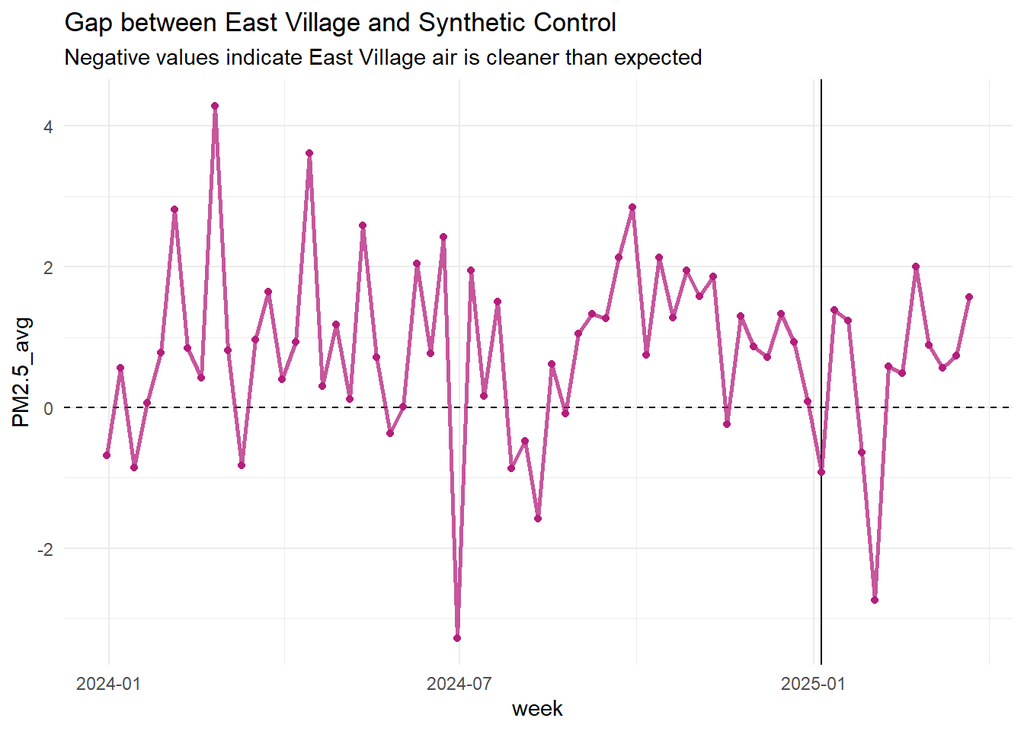

```r
# Plot 2: The Gap (Treatment Effect)
pm25_out %>% plot_differences() +
  labs(title = "Gap between East Village and Synthetic Control",
       subtitle = "Negative values indicate East Village air is cleaner than expected")
```

### Placebo Test

將其他三個控制組地區也重複做上面的操作，如果placebo gap的趨勢跟政策範圍內的差異不同，政策效果或許有效。

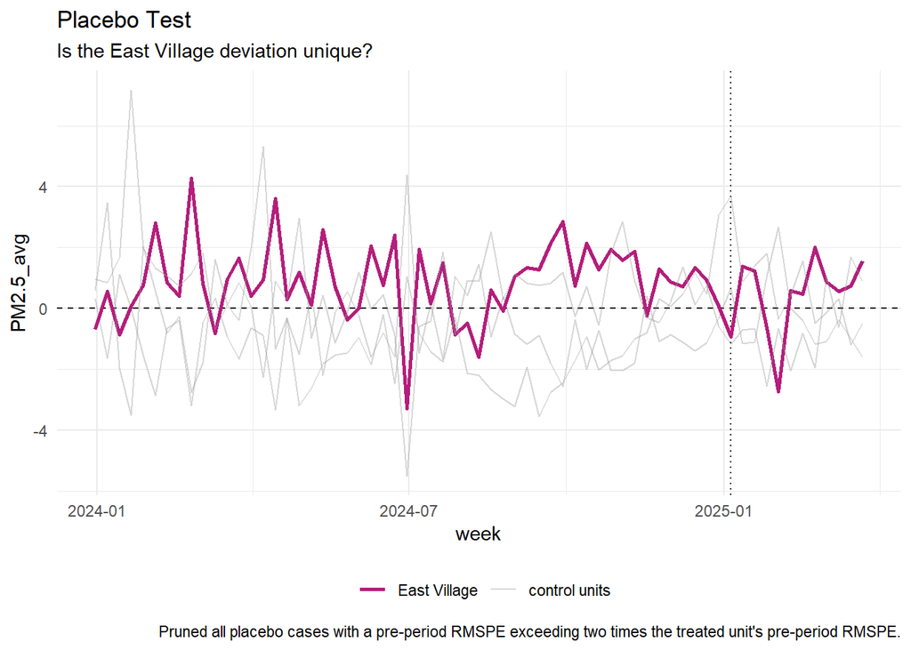

```r
# Plot 3: Placebo Test (Significance)
# This checks if the effect in East Village is larger than if we
# randomly assigned the intervention to the other regions.
pm25_out %>% plot_placebos() +
  labs(title = "Placebo Test",
       subtitle = "Is the East Village deviation unique?")
```

單純用SCM的結果，可以看到結果非常雜亂，可以說政策的效果並不顯著。

```r
# 1. Ensure dates are proper and create the 'week' variable
treatment_weekly <- treatment %>%
  select(start_date, end_date, matches("_v$")) %>%
  mutate(
    date = as.Date(end_date),
    week = floor_date(date, "week")
  ) %>%

  # 2. Aggregate to Weekly: Mean for Temp/Wind
  group_by(week) %>%
  summarise(
    temp_treat_v = mean(temp_v, na.rm = TRUE),
    wind_treat_v = mean(wind_v, na.rm = TRUE),
    # Note: Precipitation is missing in 'treatment' data; we must handle this later.
    .groups = "drop"
  ) %>%

  # Add region identifier
  mutate(region = "East Village")
```

```r
# Re-load and clean Central Park weekly data (assuming it's available)
control_weekly_full <- control %>%
  select(start_date, end_date, matches("_v$")) %>%
  mutate(
    date = as.Date(end_date),
    week = floor_date(date, "week")
  ) %>%
  group_by(week) %>%
  summarise(
    temp_avg_c = mean(temp_v, na.rm = TRUE),
    precip_total_mm = sum(precip_v, na.rm = TRUE),
    wind_avg_m_s = mean(wind_v, na.rm = TRUE),
    .groups = "drop"
  )

# Start with filtered air quality data and join Central Park data (for all regions)
scm_data_merged <- scm_data_filtered %>%
  left_join(control_weekly_full, by = "week") %>%

  # Add the specific East Village data (where region matches)
  left_join(treatment_weekly, by = c("region", "week")) %>%

  # Create final covariate columns, prioritizing East Village data where available
  mutate(
    temp_final = coalesce(temp_treat_v, temp_avg_c),
    wind_final = coalesce(wind_treat_v, wind_avg_m_s),
    precip_final = precip_total_mm # Using Central Park precip for all regions
  ) %>%
  select(-temp_treat_v, -wind_treat_v, -temp_avg_c, -wind_avg_m_s, -precip_total_mm) %>%

  # Impute remaining NA values for the predictors
  group_by(region) %>%
  fill(temp_final, wind_final, precip_final, .direction = "downup") %>%
  ungroup()

# Check: The East Village rows should have different climate values than the controls
head(scm_data_merged)
```

```
## # A tibble: 6 × 7
##   region         week       PM2.5_avg AQI_avg temp_final wind_final precip_final
##   <chr>          <date>         <dbl>   <dbl>      <dbl>      <dbl>        <dbl>
## 1 East Harlem N… 2023-12-31      8.53    47          8.2        2          164.
## 2 East Harlem N… 2024-01-07      3.04    16.8        2.9        2.6         56.4
## 3 East Harlem N… 2024-01-14     11.1     54.7        6.6        3.2        256
## 4 East Harlem N… 2024-01-21     11.7     55         -3.3        3.6         32.8
## 5 East Harlem N… 2024-01-28      3.92    21.8        4.9        2.5         94
## 6 East Harlem N… 2024-02-04      6.03    33.7        3.5        2.8         50.8
```